# advgeolab01

Shaoying Zheng

2023-10-27

# Introduction

A map based on NPP-VIIRS night light data to show the economic condition in the Michigan.

## Data Source

The Visible Infrared Imaging Radiometer Suite (VIIRS) is one of the key instruments onboard the Suomi National Polar-Orbiting Partnership (Suomi NPP) spacecraft, which was successfully launched on October 28, 2011. https://ncc.nesdis.noaa.gov/VIIRS/

Earth Observation Group had released a new consistently processed time series of annual global VIIRS nighttime lights from monthly cloud-free average radiance grids spanning 2012* to 2021. That is called VNL V2. https://eogdata.mines.edu/nighttime_light/annual/v20

## Data processing

### Grab data

Clicking on the above link, a list of annual average nighttime light will shown. To show a static economic condition based on VIIRS, we only need the image from one year. Let’s download data from 2021, and chose the average night light image.

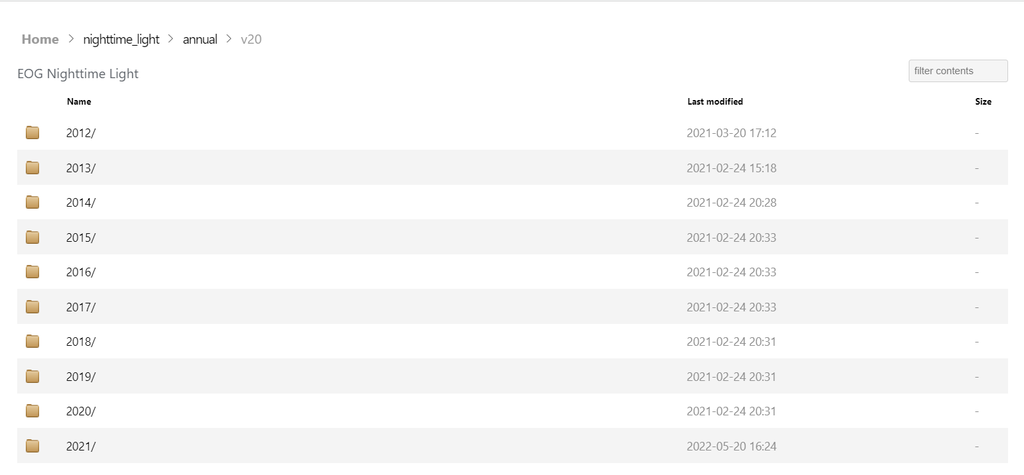

```r
library(ggplot2)
library(sf)
library(tidyverse)
```

We need to import the base map of counties in MI at first.

```r
library(tmap)
library(tigris)
```

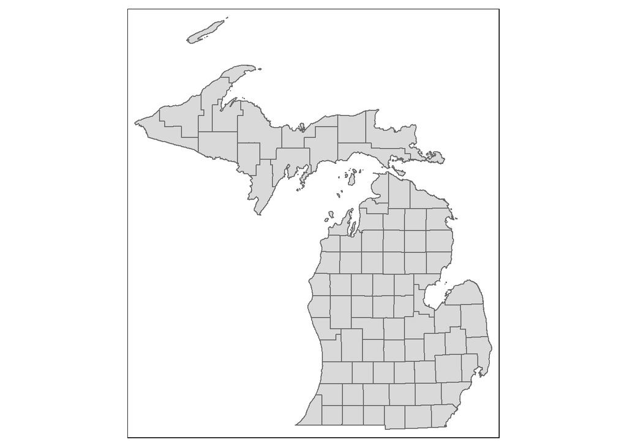

```r
us_counties <- counties(cb = TRUE) # cb: 'cartographic boundary'
michigan_counties <- subset(us_counties, STATEFP == "26")
tm_shape(michigan_counties) +
tm_polygons()
```

```r
st_write(michigan_counties,"michigan_counties.shp")
```

Then, we need to crop the raster data.

```r
library(rgdal)
library(raster)
nps <- raster("./VNL_v2_npp_2021_average_masked/VNL_v2_npp_2021_average_masked.tif")
michigan_raster <- crop(nps, extent(michigan_counties))
michigan_masked <- mask(michigan_raster, michigan_counties)
michigan_masked[michigan_masked > 256] <- 0
# writeRaster(michigan_masked, filename="michigan_masked.tif", format="GTiff", overwrite=TRUE)
```

Count mean raster value within every county to figure out which county is the most developed one. It could be calculated using R under most circumstances. But in this condition, `michigan_raster` is a Large RasterLayer, so we done this in QGIS using `zonal statistics`

```r
# Doesn't work for Large RasterLayer
library(exactextractr)
avg <- exact_extract(michigan_raster, michigan_counties, fun=c('mean'), na.rm=TRUE)
```

[figure not shown]

```r
library(dplyr)
michigan_mean <- readOGR(dsn = "michigan_mean.shp", layer = "michigan_mean")
michigan_mean_df <- as.data.frame(michigan_mean)
michigan_mean_df <- dplyr::select(michigan_mean_df, "NAME","X_mean")
michigan_mean_df <- rename(michigan_mean_df, "County_name"="NAME", "Average_Light_intensity"="X_mean")
top_counties <- michigan_mean_df %>%
  arrange(desc(Average_Light_intensity)) %>%
  head(5)
```

```r
tm_shape(michigan_masked) +
tm_raster(style="fisher",n=8, palette= "-Greys",title = "Light Intensity Index") +
tm_layout(legend.position = c(0.02,0.02),inner.margins = c(0.1,0.1,0.1,0.1)) +
tm_shape(michigan_counties) +
tm_borders() +
tm_scale_bar() +
tm_compass(position = c("right", "top"))
```

```
## stars object downsampled to 1106 by 904 cells. See tm_shape manual (argument raster.downsample)
```

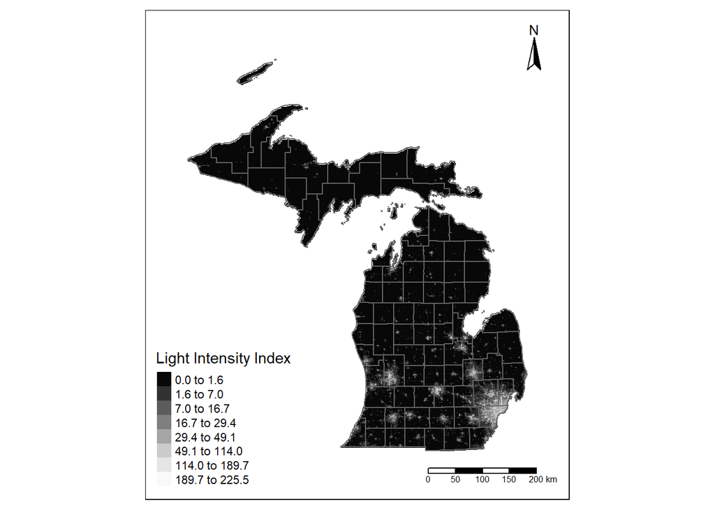

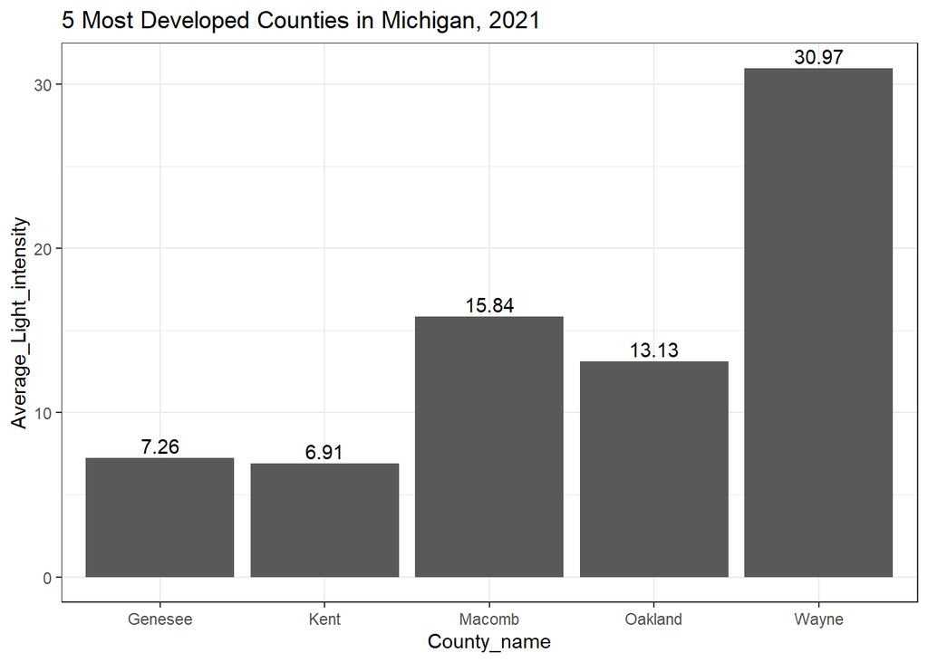

```r
library(ggplot2)
top_counties <- top_counties %>%
  arrange(desc(Average_Light_intensity))
ggplot(top_counties, aes(x = County_name, y = Average_Light_intensity)) +
  geom_bar(stat = "identity") +
  geom_text(aes(label = round(Average_Light_intensity,2)), vjust = -0.3) +
  theme_bw() +
  labs(title = "5 Most Developed Counties in Michigan, 2021")
```